# Course Project 1: Analysis of Personal Movement Data

By Francisco J. Chavez

9/13/2020

## Introduction

It is now possible to collect a large amount of data about personal movement using activity monitoring devices such as a Fitbit, Nike Fuelband, or Jawbone Up. These type of devices are part of the “quantified self” movement – a group of enthusiasts who take measurements about themselves regularly to improve their health, to find patterns in their behavior, or because they are tech geeks. But these data remain under-utilized both because the raw data are hard to obtain and there is a lack of statistical methods and software for processing and interpreting the data.

This assignment makes use of data from a personal activity monitoring device. This device collects data at 5 minute intervals through out the day. The data consists of two months of data from an anonymous individual collected during the months of October and November, 2012 and include the number of steps taken in 5 minute intervals each day.

The data for this assignment can be downloaded from the course web site:

- Dataset: [Activity monitoring data](https://d396qusza40orc.cloudfront.net/repdata%2Fdata%2Factivity.zip) [52K]

The variables included in this dataset are:

- steps: Number of steps taking in a 5-minute interval (missing values are coded as NA)
- date: The date on which the measurement was taken in YYYY-MM-DD format
- interval: Identifier for the 5-minute interval in which measurement was taken

The dataset is stored in a comma-separated-value (CSV) file and there are a total of 17,568 observations in this dataset.

## Loading and preprocessing the data

##### 1. Load the data

```r
actData <- read.csv('activity.csv', header=TRUE, sep= ",", na.strings = "NA")
```

#### 2. Process/transform the data (if necessary) into a format suitable for your analysis

```r
View(actData)
summary(actData)
```

```
##      steps            date              interval
##  Min.   :  0.00   Length:17568       Min.   :   0.0
##  1st Qu.:  0.00   Class :character   1st Qu.: 588.8
##  Median :  0.00   Mode  :character   Median :1177.5
##  Mean   : 37.38                      Mean   :1177.5
##  3rd Qu.: 12.00                      3rd Qu.:1766.2
##  Max.   :806.00                      Max.   :2355.0
##  NA's   :2304
```

```r
str(actData)
```

```
## 'data.frame':    17568 obs. of  3 variables:
##  $ steps   : int  NA NA NA NA NA NA NA NA NA NA ...
##  $ date    : chr  "2012-10-01" "2012-10-01" "2012-10-01" "2012-10-01" ...
##  $ interval: int  0 5 10 15 20 25 30 35 40 45 ...
```

```r
head(actData)
```

```
##   steps       date interval
## 1    NA 2012-10-01        0
## 2    NA 2012-10-01        5
## 3    NA 2012-10-01       10
## 4    NA 2012-10-01       15
## 5    NA 2012-10-01       20
## 6    NA 2012-10-01       25
```

```r
actData$date <- as.Date(actData$date, format = "%Y-%m-%d")
actData$interval <- factor(actData$interval)
str(actData)
```

```
## 'data.frame':    17568 obs. of  3 variables:
##  $ steps   : int  NA NA NA NA NA NA NA NA NA NA ...
##  $ date    : Date, format: "2012-10-01" "2012-10-01" ...
##  $ interval: Factor w/ 288 levels "0","5","10","15",..: 1 2 3 4 5 6 7 8 9 10 ...
```

## What is mean total number of steps taken per day

For this part of the assignment, you can ignore the missing values in the dataset

#### 1. Calculate the total number of steps taken per day

```r
NA_index <- is.na(as.character(actData$steps))
data_no_NA <- actData[!NA_index,]
head(data_no_NA)
```

```
##     steps       date interval
## 289     0 2012-10-02        0
## 290     0 2012-10-02        5
## 291     0 2012-10-02       10
## 292     0 2012-10-02       15
## 293     0 2012-10-02       20
## 294     0 2012-10-02       25
```

```r
dailySteps <- aggregate(steps ~ date, data = data_no_NA, sum)
colnames(dailySteps) <- c("date", "steps")
```

#### 2. Make a histogram of the total number of steps taken each day

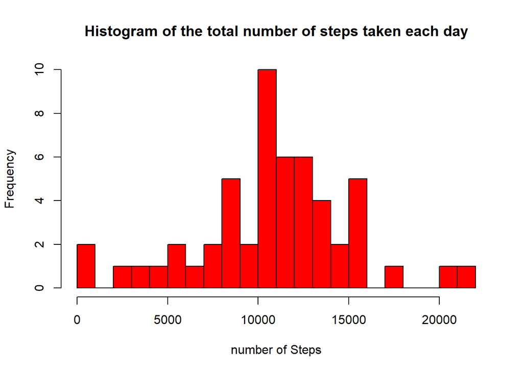

```r
hist(as.numeric(dailySteps$steps), breaks = 20, col= "red", xlab = "number of Steps", main = "Histogram of the total number of steps taken each day")
```

#### 3. Calculate and report the mean and median of the total number of steps taken per day

```r
#Mean
mean(dailySteps$steps)
```

```
## [1] 10766.19
```

```r
#Median
median(dailySteps$steps)
```

```
## [1] 10765
```

## What is the average daily activity pattern?

#### 1. Make a time series plot (i.e. type = “l”) of the 5-minute interval (x-axis) and the average number of steps taken, averaged across all days (y-axis)

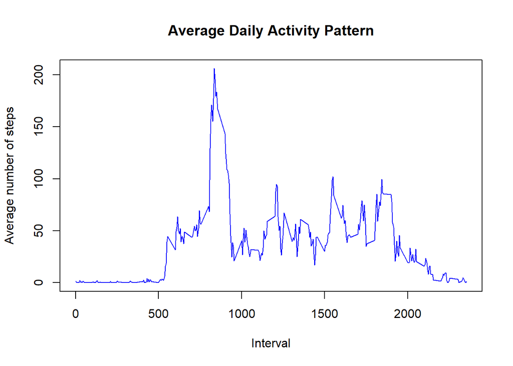

```r
#Calculate the average
steps_per_interval <- aggregate(data_no_NA$steps, by=list(interval=data_no_NA$interval), FUN=mean)

#Add Column Names
colnames(steps_per_interval) <- c("interval", "average_steps")

#plot the average of daily activity pattern
plot(as.integer(levels(steps_per_interval$interval)),  steps_per_interval$average_steps, type="l",
     xlab = "Interval", ylab = "Average number of steps", main = "Average Daily Activity Pattern", col = "blue")
```

#### 2. Which 5-minute interval, on average across all the days in the dataset, contains the maximum number of steps?

```r
#The maximum number of average steps
max_steps <- max(steps_per_interval$average_steps)
max_steps
```

```
## [1] 206.1698
```

```r
#The 5-minute interval that contains the maximum number of steps
interval_max_steps <- steps_per_interval[which.max(steps_per_interval$average_steps),]$interval
interval_max_steps
```

```
## [1] 835
## 288 Levels: 0 5 10 15 20 25 30 35 40 45 50 55 100 105 110 115 120 125 ... 2355
```

## Process Missing Values

#### 1. Calculate and report the total number of missing values in the dataset (i.e. the total number of rows with NAs)

```r
#The total number of missing values in the dataset (for each variable):
sum(is.na(as.character(actData$steps)))
```

```
## [1] 2304
```

```r
#for the "date" variable
sum(is.na(as.character(actData$date)))
```

```
## [1] 0
```

```r
#for the "interval" variable
sum(is.na(as.character(actData$interval)))
```

```
## [1] 0
```

#### 2. Devise a strategy for filling in all of the missing values in the dataset. The strategy does not need to be sophisticated. For example, you could use the mean/median for that day, or the mean for that 5-minute interval, etc.

```r
NA_index <- which(is.na(as.character(actData$steps)))
View(NA_index)
complete_data <- actData

summary(complete_data)
```

```
##      steps             date               interval
##  Min.   :  0.00   Min.   :2012-10-01   0      :   61
##  1st Qu.:  0.00   1st Qu.:2012-10-16   5      :   61
##  Median :  0.00   Median :2012-10-31   10     :   61
##  Mean   : 37.38   Mean   :2012-10-31   15     :   61
##  3rd Qu.: 12.00   3rd Qu.:2012-11-15   20     :   61
##  Max.   :806.00   Max.   :2012-11-30   25     :   61
##  NA's   :2304                          (Other):17202
```

```r
str(complete_data)
```

```
## 'data.frame':    17568 obs. of  3 variables:
##  $ steps   : int  NA NA NA NA NA NA NA NA NA NA ...
##  $ date    : Date, format: "2012-10-01" "2012-10-01" ...
##  $ interval: Factor w/ 288 levels "0","5","10","15",..: 1 2 3 4 5 6 7 8 9 10 ...
```

#### 3. Create a new dataset that is equal to the original dataset but with the missing data filled in.

```r
complete_data[NA_index, ]$steps <- unlist(lapply(NA_index, FUN=function(NA_index){
  steps_per_interval[actData[NA_index,]$interval==steps_per_interval$interval,]$average_steps
}))

#Create a data frame with the steps taken for each day
steps_each_day_complete <- aggregate(steps ~ date, data = complete_data, sum)

#Adding column names to the created data frame
colnames(steps_each_day_complete) <- c("date", "steps")
```

#### 4. Make a histogram of the total number of steps taken each day and Calculate and report the mean and median total number of steps taken per day.

Do these values differ from the estimates from the first part of the assignment? What is the impact of imputing missing data on the estimates of the total daily number of steps?

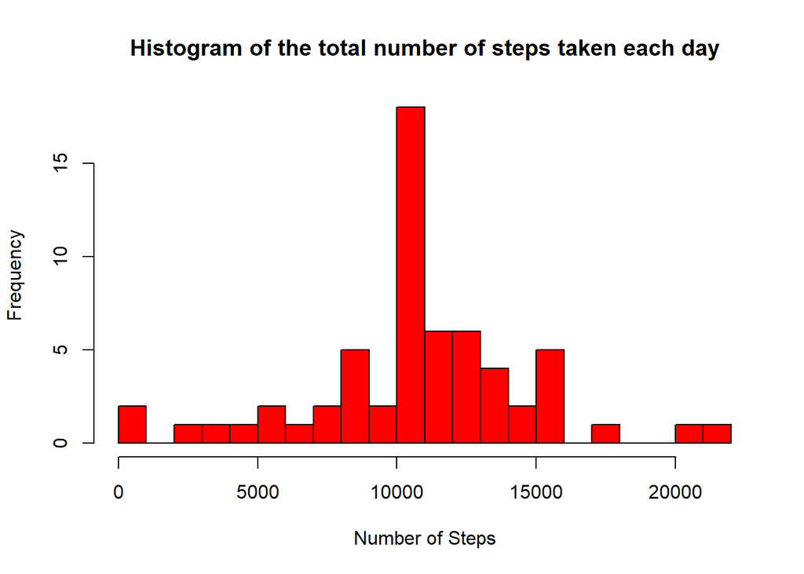

```r
#Making the histogram
hist(as.numeric(steps_each_day_complete$steps), breaks = 20, col = "red", xlab = "Number of Steps", main = "Histogram of the total number of steps taken each day")
```

```r
#Mean
mean(steps_each_day_complete$steps)
```

```
## [1] 10766.19
```

```r
#Median
median(steps_each_day_complete$steps)
```

```
## [1] 10766.19
```

The mean value are equal for both datasets. The median shifted by 1 from 10765 to 10766. Thus there is minimal impact on the estimates of the total daily number of steps.

## Are there differences in activity patterns between weekdays and weekends?

For this part the weekdays() function may be of some help here. Use the dataset with the filled-in missing values for this part.

#### 1. Create a new factor variable in the dataset with two levels – “weekday” and “weekend” indicating whether a given date is a weekday or weekend day.

```r
#create factor variable
complete_data$day <- as.factor(weekdays(complete_data$date))

#create logical variable
complete_data$is_weekday <- ifelse(!(complete_data$day %in% c("Satuday", "Sunday")), TRUE, FALSE)

#Calculate average number of weekdays
weekdays_data <- complete_data[complete_data$is_weekday,]
View(weekdays_data)
steps_per_interval_weekdays <- aggregate(weekdays_data$steps, by=list(interval=weekdays_data$interval), FUN= mean)
View(steps_per_interval_weekdays)

#Calculate the average number of steps for weekends
weekends_data <- complete_data[!complete_data$is_weekday,]
View(weekends_data)
steps_per_interval_weekends <- aggregate(weekends_data$steps, by=list(interval=weekends_data$interval), FUN= mean)
View(steps_per_interval_weekends)

#Adding column Names
colnames(steps_per_interval_weekdays) <- c("interval", "average_steps")
colnames(steps_per_interval_weekends) <- c("interval", "average_steps")

#Adding Column to indicate day of the week
steps_per_interval_weekdays$day <- "Weekday"
steps_per_interval_weekends$day <- "Weekend"

#Merge the two data sets
week_data <- rbind(steps_per_interval_weekends, steps_per_interval_weekdays)
View(week_data)

#Convert the day variable to factor type
week_data$day <- as.factor(week_data$day)
```

#### 2. Make a panel plot containing a time series plot (i.e. type = “l”) of the 5-minute interval (x-axis) and the average number of steps taken, averaged across all weekday days or weekend days (y-axis).

See the README file in the GitHub repository to see an example of what this plot should look like using simulated data.

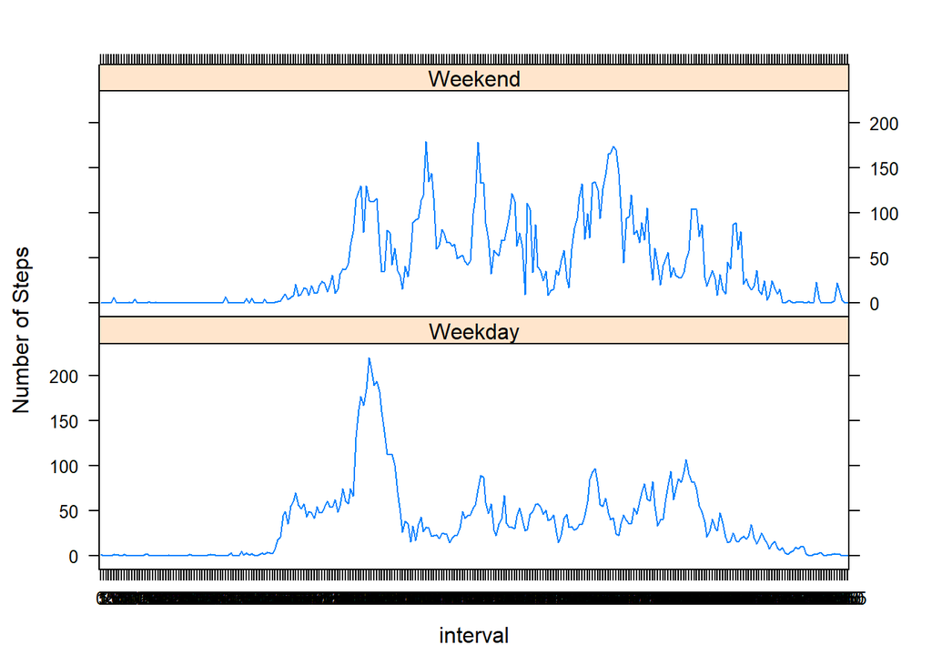

```r
#Plot number of steps vs Interval for weekends and weekdays

xyplot(average_steps ~ interval | day, data = week_data, layout = c(1,2), type= "l", ylab="Number of Steps")
```